# Introduction to Bayes Rules and Bayesian Reasoning

In this workbook we introduce the basic concepts of conditional probability, Bayes Rule, and then discuss how these ideas can be used to reason about data and probabilities.

# 1 Basic Concepts

Suppose we have two related but separate random variables, $A$ and $B$ of interest. The two variables need not be independent, but they do represent separate concepts.

Rather than reasoning in the abstract, we should make things more concrete.

Thus, we let these two variables be binary - that is, they only take two values (TRUE and FALSE say) - and let $A$ represent whether or not a patient is infected by a virus, and $B$ represents whether or not that patient tests positive for that viral infection.

These two things are related but they are not the same - a person could be infected with the virus and still test negative, and so on.

With this setup, we wish to assess the probabilities of observing values of these variables.

## 1.1 Phase Space

This system is represented by a two-dimensional space - called *phase space* - the space of all possible values of the variables. In this case, two binary variables, phase space has four possible configurations:

$$(A, B), \; (A, \neg B), \; (\neg A, B), \; (\neg A, \neg B)$$

When we have random variables, we fully solve this system by determining the probabilities for all the possible values in phase space.

## 1.2 Medical Tests

We use tests for a virus as a way to illustrate these concepts, and use these ideas to show broad-stroke differences between the various tests.

First, we need to determine our naming:

- $A$ is the variable determining the presence of the viral infection (TRUE signifying person is infected)
- $B$ is the variable showing the result of the detection test (TRUE signifying the test detected the viral infection)

As mentioned, no test is perfect. An uninfected person can test positive (called a False Positive), and an infected person could produce a negative test (a False Negative). The quality of a given test is determined by the probabilities of it giving false results. We know these in advance and can then use them to determine the ‘correctness’ of a test result.

## 1.3 Conditional Probability

Before we proceed, we introduce *conditional probability*, the probability of an event given known information.

We have a number of ways of denoting this, such as $P(A \, | \, B = b)$, which is the probability of $A$ given that we know the value of $B$ is $b$.

More generally, we can denote the conditional probability of $A$ given information on $B$ as $P(A \, | \, B)$.

Note that this concept is not symmetric:

$$P(A \, | \, B) \ne P(B \, | \, A)$$

This is important, as it is easy to get these confused and our intuitions often lead us in the wrong direction.

To calculate conditional probability, we need to narrow down the state space to only those values that correspond to our given information, and then calculate the probability in this subspace.

More formally:

$$P(A \, | \, B) = \frac{P(A \cap B)}{P(B)} \\
P(B \, | \, A) = \frac{P(B \cap A)}{P(A)}$$

## 1.4 Bayes Rule

We derive Bayes Rule from these basic definitions of conditional probability:

$$P(A \, | \, B) = \frac{P(A \cap B)}{P(B)} \implies P(A \cap B) = P(A \, | \, B) \, P(B)$$

This does make a certain amount of intuitive sense: to calculate the probability of observing both $A$ AND $B$, we take each possible values of $B$, calculate the conditional probabilities in each case. Our final probability is the weighted sum of the possible outcomes.

However, while conditional probability is not symmetric, intersection is.

That is,

$$P(A \cap B) = P(B \cap A)$$

Therefore,

$$P(B \, | \, A) \, P(A) = P(A \, | \, B) \, P(B)$$

Finally, we get to the discrete case for Bayes Rules:

$$P(A \, | \, B) = \frac{P(B \, | \, A) \, P(A)}{P(B)}$$

Close inspection of this shows us that Bayes rule gives us a way to ‘invert’ our probabilities. In fact, early works on this often referred to the above as the ‘method of inverse probabilities’.

## 1.5 Bayes Rule with Continuous Variables

We now want to consider the case when our random variables are continuous rather than discrete-valued. Fortunately, we can follow a similar logic, using integrals rather than sums.

$$p(A \, | \, B) = \frac{\int p(B \, | \, A) \, p(A)}{\int p(B)}$$

In most cases however we can ignore the denominator (the “normalising constant”) as in most cases it is irrelevant for our analysis.

Finally, in practical data analysis, we want to draw inferences on unknown parameters $\theta$ in the model from observed data, $D$.

$$p(\theta \, | \, D) = \int p(\theta) \, p(D \, | \, \theta)$$

In the above formula, we have

- $p(\theta \, | \, D)$ is the ‘un-normalised’ *posterior distribution* for $\theta$,
- $p(D \, | \, \theta)$ is the *likelihood model*,
- $p(\theta)$ is the *prior distribution* for $\theta$.

Thus, we combine a prior distribution over $\theta$ with a likelihood model for the data $D$ to calculate the posterior distribution for $\theta$.

This means that performing Bayesian analysis in the real-world needs a way to perform those integrations. In this workshop series we use Stan to sample from these posteriors.

# 2 Illustrating the Concepts

The above section focused mostly on conceptual ideas, and it is often useful to illustrate these ideas via computation and simulation.

We start with simulating medical tests, using some input values.

For the following work, we assume the prevalence of the virus is 1% of the population.

## 2.1 Construct First Simulations

As discussed previously, we denote $A$ as the presence/absence of the virus in the patient (presence denotes infection), and $B$ as the results of the test for presence (a TRUE value means the test detected the virus).

As discussed previously, while related, these two variables are separate, an uninfected person could test positive and vice versa.

So, a person takes a test and tests positive - what is the probability that the patient is infected? How do we go about calculating this?

In mathematical notation, we want to calculate

$$P(A = \text{infected} \, | B = \text{positive test})$$

Test efficacy is stated in terms of two numbers, the rate of false positives and false negatives, that is,

$$P(B = \text{positive test} \, | \, A = \text{infected})$$

and

$$P(B = \text{negative test} \, | \, A = \text{not infected}).$$

Let us suppose that a gold-standard medical test typically has a 5% rate for both.

Finally, we also need to know the prevalence of the disease in the population, the unconditional probability of a patient having the disease.

Let us assume this prevalence is 1%.

```r
n_sim <- 1e7

prevalence    <- 0.01
prop_falsepos <- 0.05
prop_falseneg <- 0.05

population_tbl <- generate_medical_test_data(
    n_patient = n_sim,
    prevalence = prevalence,
    falsepos   = prop_falsepos,
    falseneg   = prop_falseneg
    )

population_tbl %>% glimpse()
```

```
## Rows: 10,000,000
## Columns: 3
## $ patient_id  <int> 1, 2, 3, 4, 5, 6, 7, 8, 9, 10, 11, 12, 13, 14, 15, 16, 17,…
## $ infected    <lgl> FALSE, FALSE, FALSE, FALSE, FALSE, FALSE, FALSE, FALSE, FA…
## $ test_result <lgl> FALSE, FALSE, FALSE, FALSE, FALSE, FALSE, FALSE, FALSE, FA…
```

Now we check the simulation proportions conditioning on the test result.

```r
population_tbl %>%
  count(infected, test_result, name = "sim_count") %>%
  group_by(test_result) %>%
  mutate(
    ref_count = sum(sim_count),
    prop      = round(sim_count / ref_count, 6)
    )
```

```
## # A tibble: 4 × 5
## # Groups:   test_result [2]
##   infected test_result sim_count ref_count    prop
##   <lgl>    <lgl>           <int>     <int>   <dbl>
## 1 FALSE    FALSE         9404953   9409845 0.999
## 2 FALSE    TRUE           495538    590155 0.840
## 3 TRUE     FALSE            4892   9409845 0.00052
## 4 TRUE     TRUE            94617    590155 0.160
```

So, according to this simulation the probability of a True Positive is about 16%.

Please note that all of this ignores a whole lot of real issues with testing! But it does highlight a problem with medical testing that needs to be accounted for in designing them - that is, the “low base rate fallacy”. But we ignore all these issues for now.

## 2.2 Analytical Calculation

We now use Bayes Rule to calculate this probability analytically and compare it to our simulated value.

$$P(A \, | \, B = \text{positive}) = \frac{P(B \, | \, A) \, P(A)}{P(B)}$$

We know most of these quantities except for the denominator $P(B)$, but we can calculate this from the values we do know:

$$P(B) = P(B \, | A = \text{infected}) \, P(A = \text{infected}) +
P(B \, | A = \text{not infected}) \, P(A = \text{not infected})$$

We can now plug all these values in to calculate that conditional probability.

$$\begin{eqnarray*}
P(A = \text{infected} \, | \, B = \text{positive})
&=& \frac{P(B \, | \, A) \, P(A)}
{P(B \, | \, A) \, P(A) + P(B \, | \, \neg A) \, P(\neg A)} \\
\\
&=& \frac{(0.95)(0.01)}{(0.95)(0.01) + (0.05)(0.99)} \\
\\
&=& 0.1610
\end{eqnarray*}$$

# 3 Effect of Prevalance

Before we move on from this, we want to investigate the impact of the prevalence of the disease on the efficacy of the test.

We do this by fixing our probabilities for both false positive and false negatives and then vary the prior probability (which is the prevalence in the overall population)

To do this, we calculate the analytical posterior probability using a function, as this should speed things up considerably.

```r
calculate_analytic_posterior_probability <- function(
  prevalence, false_positive = 0.05, false_negative = 0.05) {

  t1 = (1 - false_positive) * prevalence
  t2 = (false_negative) * (1 - prevalence)

  posterior_prob = t1 / (t1 + t2)

  return(posterior_prob)
}
```

We quickly check this function using our existing parameters.

```r
calculate_analytic_posterior_probability(
  prevalence     = 0.01,
  false_positive = 0.05,
  false_negative = 0.05
  )
```

```
## [1] 0.1610169
```

This matches what we had done before, so it seems to work. Let’s also check what the calculated probability is if there are no false negatives.

```r
calculate_analytic_posterior_probability(
  prevalence     = 0.01,
  false_positive = 0.05,
  false_negative = 0.00
  )
```

```
## [1] 1
```

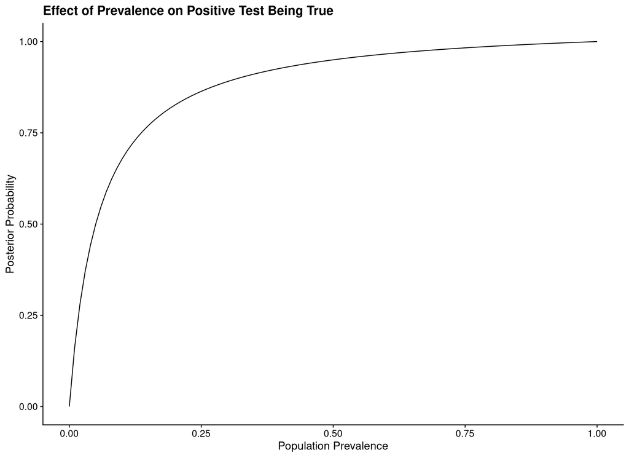

```r
prevalence_vec <- seq(0, 1, by = 0.01)

pop_prev_tbl <- tibble(prevalence = prevalence_vec) %>%
  mutate(
    posterior_prob = map_dbl(
      prevalence, calculate_analytic_posterior_probability,
      false_positive = 0.05,
      false_negative = 0.05
      )
    )

ggplot(pop_prev_tbl) +
  geom_line(aes(x = prevalence, y = posterior_prob)) +
  labs(
    x = "Population Prevalence",
    y = "Posterior Probability",
    title = "Effect of Prevalence on Positive Test Being True"
    )
```

We now repeat this calculation to check for the effect of false positives on this posterior probability.

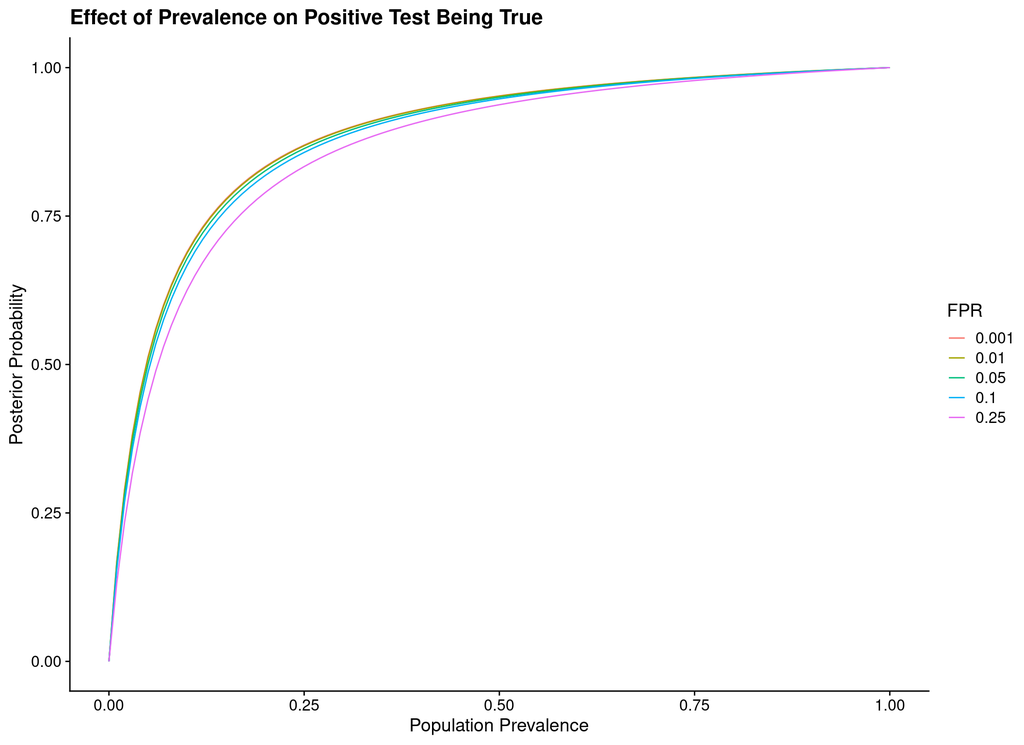

```r
pop_prev_tbl <- expand_grid(
    prevalence = prevalence_vec,
    false_pos  = c(0.001, 0.01, 0.05, 0.10, 0.25)
    ) %>%
  mutate(
    posterior_prob = map2_dbl(
      prevalence, false_pos,
      calculate_analytic_posterior_probability,
      false_negative = 0.05
      )
    )

ggplot(pop_prev_tbl %>% mutate(false_pos = false_pos %>% as.character())) +
  geom_line(aes(x = prevalence, y = posterior_prob, colour = false_pos)) +
  labs(
    x = "Population Prevalence",
    y = "Posterior Probability",
    colour = "FPR",
    title = "Effect of Prevalence on Positive Test Being True"
    )
```

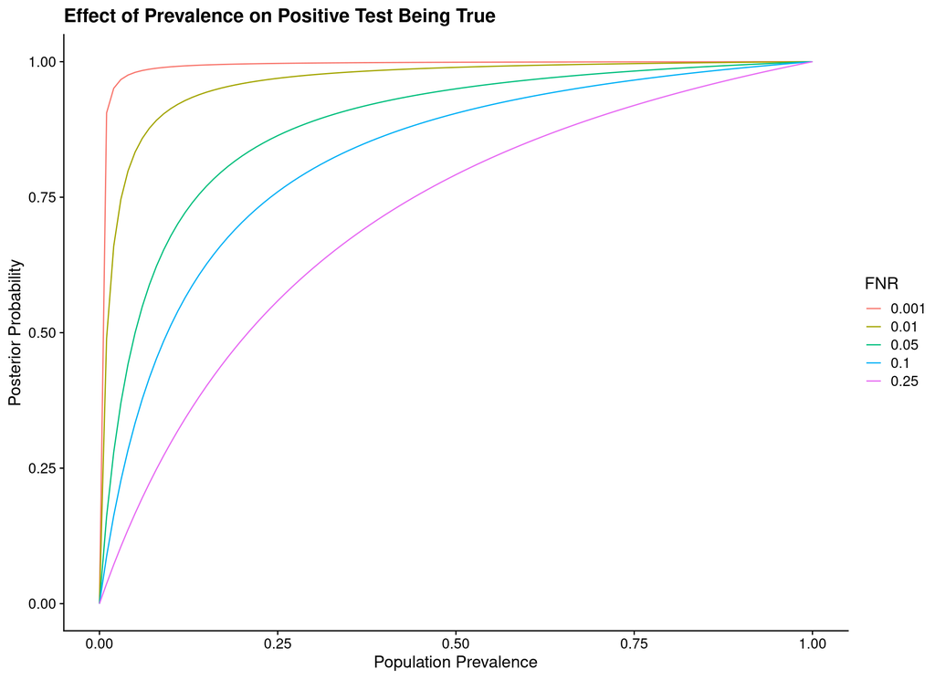

```r
pop_prev_tbl <- expand_grid(
    prevalence = prevalence_vec,
    false_neg  = c(0.001, 0.01, 0.05, 0.10, 0.25)
    ) %>%
  mutate(
    posterior_prob = map2_dbl(
      prevalence, false_neg,
      calculate_analytic_posterior_probability,
      false_positive = 0.05
      )
    )

ggplot(pop_prev_tbl %>% mutate(false_neg = false_neg %>% as.character())) +
  geom_line(aes(x = prevalence, y = posterior_prob, colour = false_neg)) +
  labs(
    x = "Population Prevalence",
    y = "Posterior Probability",
    colour = "FNR",
    title = "Effect of Prevalence on Positive Test Being True"
    )
```

Finally, we want to see the two-way effect of different positive rates at different levels of prevalence.

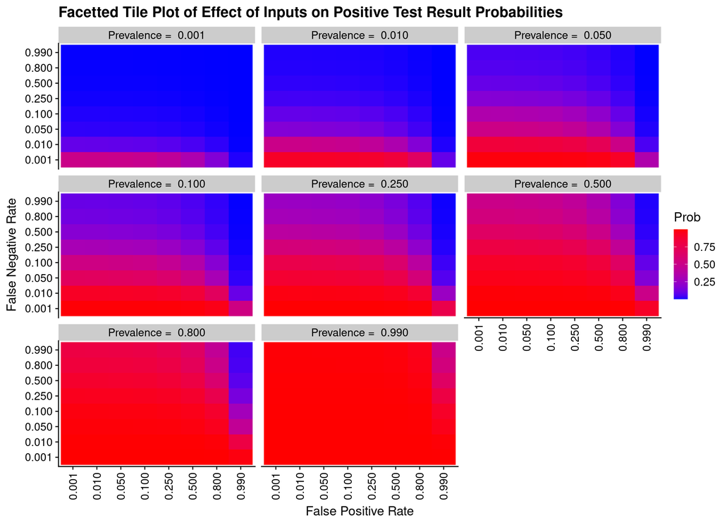

```r
prob_vals <- c(0.001, 0.01, 0.05, 0.10, 0.25, 0.50, 0.80, 0.99)

postprob_data_tbl <- expand_grid(
    prevalence = prob_vals,
    false_pos  = prob_vals,
    false_neg  = prob_vals
    ) %>%
  mutate(
    posterior_prob = pmap_dbl(
      list(
        prevalence = prevalence,
        false_positive = false_pos,
        false_negative = false_neg
        ),
      calculate_analytic_posterior_probability
      ),

    prevalence_label = sprintf("Prevalence = %6.3f", prevalence)
    )

ggplot(postprob_data_tbl %>% mutate(across(c(false_pos, false_neg), ~ sprintf("%6.3f", .x)))) +
  geom_tile(aes(x = false_pos, y = false_neg, fill = posterior_prob)) +
  facet_wrap(vars(prevalence_label)) +
  scale_fill_gradient(low = "blue", high = "red") +
  labs(
    x = "False Positive Rate",
    y = "False Negative Rate",
    fill = "Prob",
    title = "Facetted Tile Plot of Effect of Inputs on Positive Test Result Probabilities"
    ) +
  theme(
    axis.text.x = element_text(angle = 90, vjust = 0.5)
    )
```

# 4 R Environment

```r
options(width = 100L)
```

```r
options(width = 80L)
```